# latin_america

Juan Carlos Villaseñor-Derbez

Last update 2018-05-10

# Ideal outline:

- EEZ-ecoregions
- Create a shapefile of ecoregions broken down by EEZ `st_intersection()`
- Calculate the area of these new pieces `st_area()`
- MPAs
- For polygons
  - Break every MULTIPOLYGON into single POLYGONS `st_cast()`
  - Calculate the area of each of these new polygons
- For points
  - Create a buffer arround the point, with a radius that creates an equivalent area
  - Convert buffer into a polygon
  - Make sure area of polygon is the same as area in the data
  - Make sure to have an object of class POLYGON and not MULTIPOLYGON
- Put polygons and points (now also polygons) together
- Break these new polygons by the eez-ecoregion polygons calculated before
- Group_by eez-ecoregion and calculate total and relative protection
- Fishing effort
- Mask fishing effort points to keep things within each eez-ecoregion
- Put these together

# Housekeeping

```r
## Clear the environment
rm(list = ls())

# Load packages
suppressPackageStartupMessages({
  library(janitor)
  library(here)
  library(lwgeom)
  library(sf)
  library(tidyverse)
})

# Source functions
source(here("scripts","sfc_as_cols.R"))

deg2rad <- function(deg){
  (deg * pi) / (180)
  }
```

```r
proj <- "+proj=longlat +datum=WGS84 +no_defs +ellps=WGS84 +towgs84=0,0,0"

countries <- c("MEX", "GTM", "SLV", "HND", "NIC", "CRI", "PAN", "COL","PER", "ECU", "CHL")
```

```r
coastline <- st_read(dsn = here("data", "spatial"),
                     layer = "world_coastline",
                     quiet = T,
                     stringsAsFactors = F) %>%
  filter(iso3 %in% countries) %>%
  mutate(coastline = 1) %>%
  group_by(coastline) %>%
  summarize(n = n())
```

# Part1 EEZ Ecoregions

## Create a shapefile of ecoregions broken down by EEZ `st_intersection()`

Load EEZ data, filter by countries we want, reproject and keep only relevant variables

```r
EEZ <- read_sf(dsn = here("raw_data","spatial","World_EEZ_v10_20180221"),
               layer = "eez_v10",
               quiet = T,
               stringsAsFactors = F) %>%
  clean_names() %>%
  filter(iso_ter1 %in% countries) %>%
  st_simplify(dTolerance = 0.1)%>%
  st_transform(crs = proj) %>%
  select(iso3 = iso_ter1)
```

Load ecoregions data, fix names, and reproject

```r
meow <- read_sf(dsn = here("raw_data","spatial","MEOW"),
                layer = "meow_ecos",
                quiet = T,
                stringsAsFactors = F) %>%
  janitor::clean_names() %>%
  st_transform(crs = proj)
```

Break ecoregions and EEZ by areas where they intersect, calculate the area and create a code name for each new polygon

```r
eez_ecoregion <- EEZ %>%
  st_intersection(meow) %>%
  mutate(area = st_area(.),
         eez_ecoregion_area = as.numeric(area) / 1e6,
         eez_ecoregion = paste(iso3, ecoregion, sep = "_")) %>%
  select(iso3, eez_ecoregion, realm, province, ecoregion, eez_ecoregion_area)
```

```
## although coordinates are longitude/latitude, st_intersection assumes that they are planar
```

Visualize the new parts

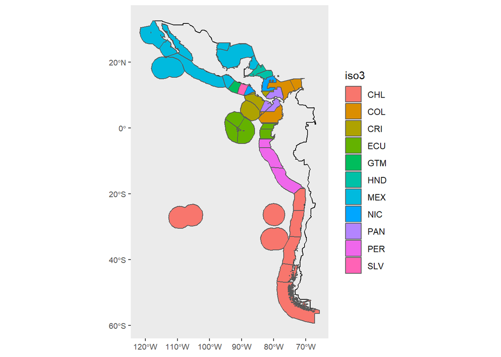

```r
ggplot() +
  geom_sf(data = coastline, color = "black", fill = "transparent") +
  geom_sf(data = eez_ecoregion, aes(fill = iso3)) +
  theme(panel.grid.major = element_line(colour = "transparent"),
        axis.text = element_text(size = 8))
```

# Part 2 MPAS

## For polygons

Break every MULTIPOLYGON into single POLYGONS `st_cast()` and calculate the area of each of these new polygons. As soon as we read, we filter out undesired countries and iucn categories. We validate all polygons and proceed to `cast` each MPA into individual polygons. Then we calculate the individual area of eachnew polygon and reproject. We finilize by selecting the variables we care about.

```r
mpa_poly <- read_sf(dsn = here("raw_data","spatial","WDPA_Mar2018"),
                    layer = "WDPA_Mar2018_marine-shapefile-polygons",
                    quiet = T,
                    stringsAsFactors = F) %>%
  janitor::clean_names() %>%
  filter(iso3 %in% countries) %>%
  st_make_valid() %>%
  st_cast(to = "POLYGON") %>%
  mutate(mpa_area = st_area(.),
         mpa_area = as.numeric(mpa_area) / 1e6) %>%
  st_transform(crs = proj) %>%
  select(wdpaid, name, iucn_cat, mpa_area) %>%
  mutate(source = "polygons")
```

## For points

Create a buffer arround the point, with a radius that creates an equivalent area Convert buffer into a polygon Make sure area of polygon is the same as area in the data Make sure to have an object of class POLYGON and not MULTIPOLYGON

```r
mpa_points <- read_sf(dsn = here("raw_data", "spatial", "WDPA_Mar2018"),
                      layer = "WDPA_Mar2018_marine-shapefile-points",
                      quiet = T,
                      stringsAsFactors = F) %>%
  janitor::clean_names() %>%
  filter(iso3 %in% countries) %>%
  select(wdpaid, name, iucn_cat, rep_m_area, rep_area) %>%
  sfc_as_cols(names = c("lon", "lat")) %>%
  mutate(radius = (sqrt(rep_area / pi)) / (cos(deg2rad(lat)) * 111.32)) %>%
  st_buffer(dist = .$radius) %>%
  mutate(test_area = st_area(.),
         test_area = as.numeric(test_area) / 1e6,
         diff = test_area - rep_area)
```

```
## dist is assumed to be in decimal degrees (arc_degrees).
```

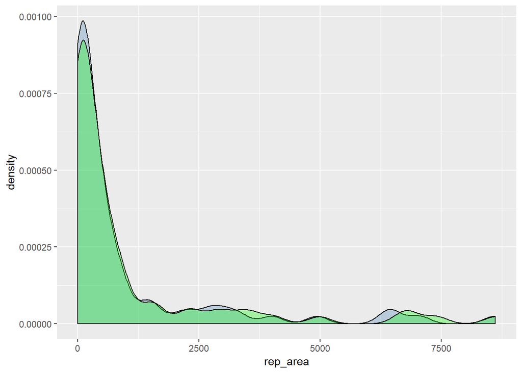

```r
ggplot(mpa_points) +
  geom_density(aes(x = rep_area), fill = "steelblue", alpha = 0.3) +
  geom_density(aes(x = test_area), fill = "green", alpha = 0.3)
```

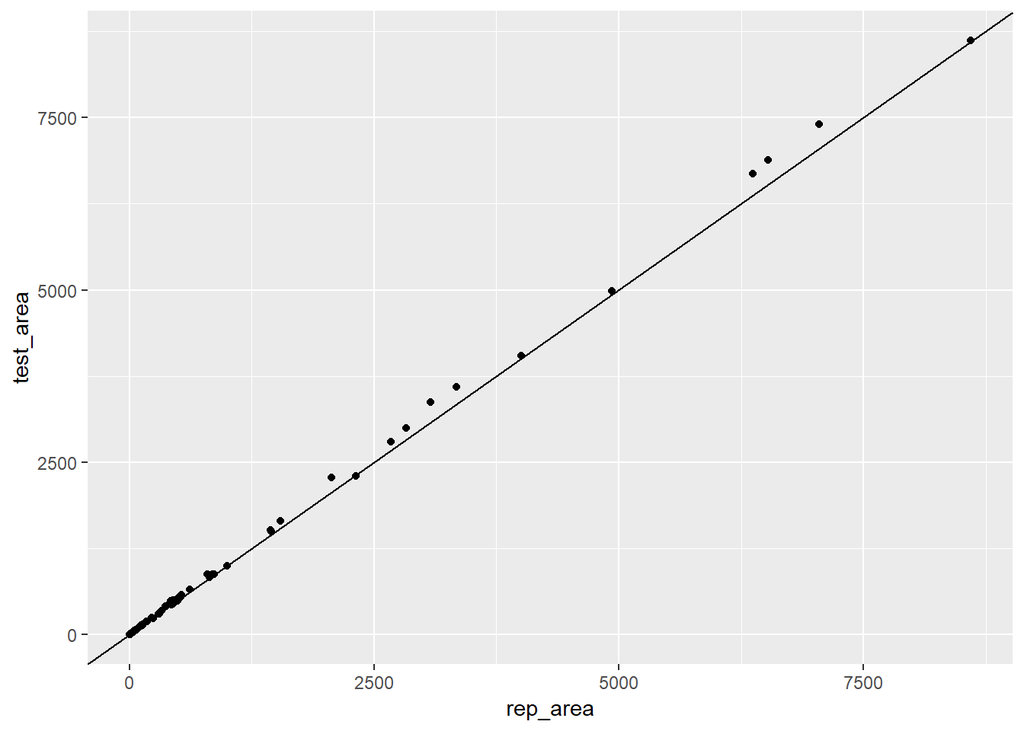

```r
ggplot(mpa_points, aes(x = rep_area, y = test_area)) +
  geom_point() +
  geom_abline()
```

```r
mpa_points <- mpa_points %>%
  st_transform(crs = proj) %>%
  select(wdpaid, name, iucn_cat, mpa_area = rep_area) %>%
  mutate(source = "points")
```

Put polygons and points (now also polygons) together Break these new polygons by the eez-ecoregion polygons calculated before Group_by eez-ecoregion and calculate total and relative protection

```r
eez_ecoregion_protection <- rbind(mpa_poly, mpa_points) %>%
  st_intersection(eez_ecoregion) %>%
  mutate(cropped_mpa_area = st_area(.),
         cropped_mpa_area = as.numeric(cropped_mpa_area / 1e6)) %>%
  group_by(eez_ecoregion, eez_ecoregion_area) %>%
  summarize(total_protected = sum(cropped_mpa_area)) %>%
  ungroup() %>%
  mutate(percent_protected = total_protected / eez_ecoregion_area) %>%
  st_set_geometry(NULL) %>%
  select(eez_ecoregion, total_protected, percent_protected)
```

```
## although coordinates are longitude/latitude, st_intersection assumes that they are planar
```

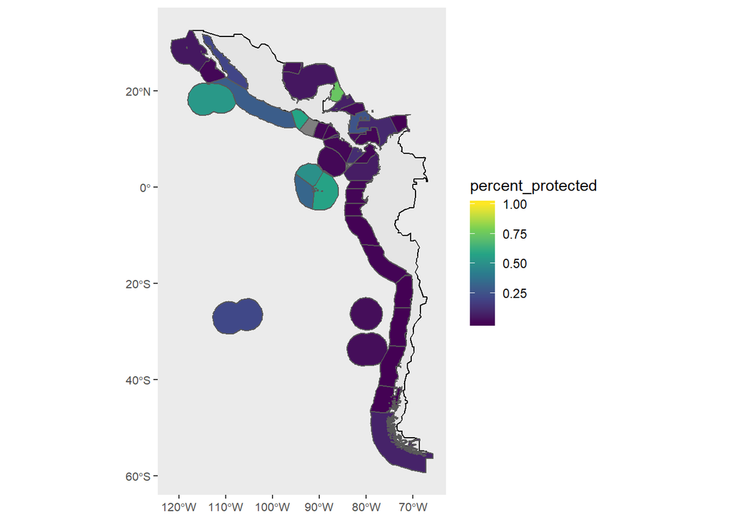

```r
temp <- eez_ecoregion %>%
  left_join(eez_ecoregion_protection, by = "eez_ecoregion")

ggplot() +
  geom_sf(data = coastline, color = "black") +
  geom_sf(data = temp, aes(fill = percent_protected)) +
  scale_fill_viridis_c() +
  theme(panel.grid.major = element_line(colour = "transparent"),
        axis.text = element_text(size = 8))
```

# Part 3 Fishing effort

First I read in the fishing effort

```r
mean_binned_fishing <- read.csv(here("data", "mean_yearly_fishing_effort.csv")) %>%
  filter(mean_fishing_hours > 0)
```

Mask fishing effort points to keep things within each eez-ecoregion

```r
masked_mean_binned_fishing <- mean_binned_fishing %>%
  filter(between(lon_bin, -118, -55),
         between(lat_bin, -67, 33)) %>%
  st_as_sf(coords = c("lon_bin", "lat_bin"), crs = proj) %>%
  st_intersection(y = eez_ecoregion) %>%
  sfc_as_cols(names = c("lon", "lat")) %>%
  st_set_geometry(NULL) %>%
  group_by(eez_ecoregion, eez_ecoregion_area) %>%
  summarize(hours = sum(mean_fishing_hours)) %>%
  ungroup() %>%
  mutate(norm_hours = hours / eez_ecoregion_area)
```

```
## although coordinates are longitude/latitude, st_intersection assumes that they are planar
```

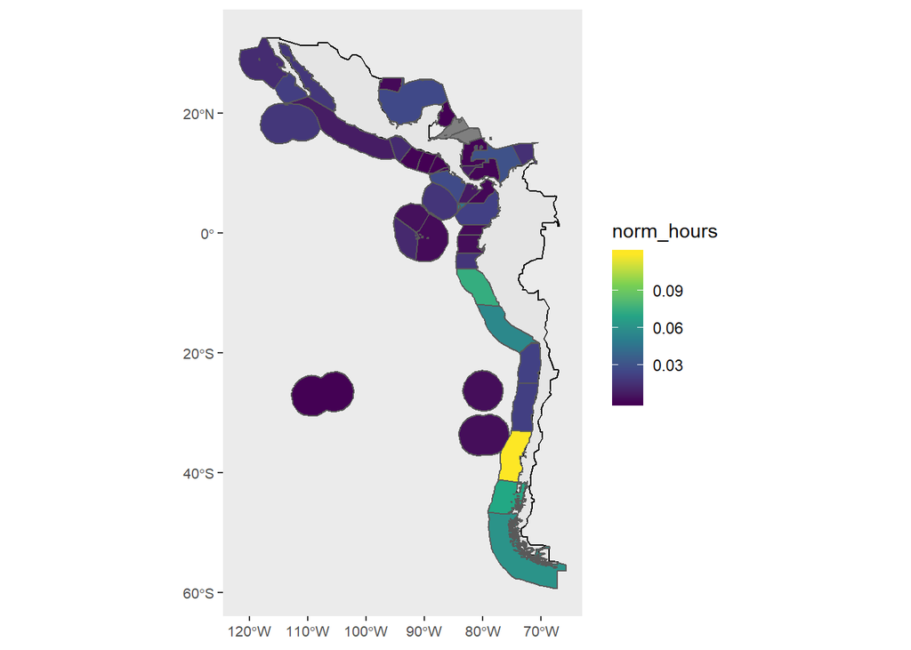

```r
temp2 <- eez_ecoregion %>%
  left_join(masked_mean_binned_fishing, by = "eez_ecoregion")

ggplot() +
  geom_sf(data = coastline, color = "black") +
  geom_sf(data = temp2, aes(fill = norm_hours)) +
  scale_fill_viridis_c() +
  theme(panel.grid.major = element_line(colour = "transparent"),
        axis.text = element_text(size = 8))
```

## Masterplot

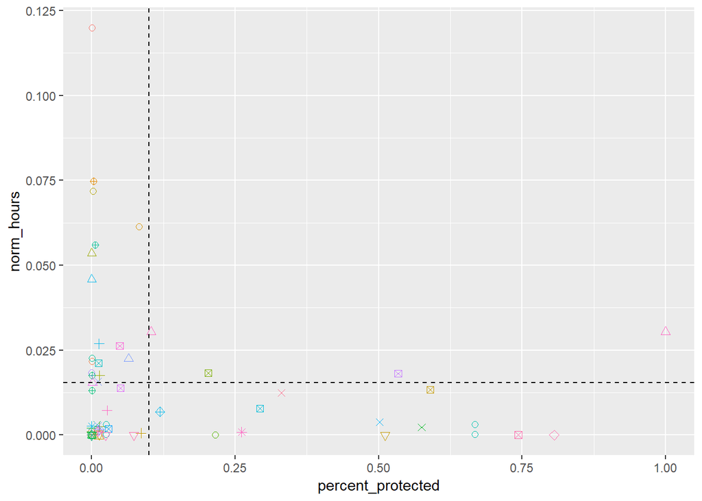

```r
masterdata <- eez_ecoregion %>%
  left_join(masked_mean_binned_fishing, by = "eez_ecoregion") %>%
  left_join(eez_ecoregion_protection, by = "eez_ecoregion") %>%
  replace_na(replace = list(norm_hours = 0, percent_protected = 0))

ggplot(masterdata, aes(x = percent_protected, y = norm_hours, color = ecoregion, shape = iso3)) +
  geom_point(size = 2) +
  geom_vline(xintercept = 0.1, linetype = "dashed") +
  geom_hline(aes(yintercept = mean(norm_hours, na.rm = T)), linetype = "dashed") +
  scale_shape_manual(values = c(1:11)) +
  theme(legend.position = "none")
```